# IE Project

yunus emre erdogan , ugur uzunoglu

02 07 2021

[output not shown]

[output not shown]

[output not shown]

[output not shown]

# Introduction

One holy question rises from the Misty Mountains : How many products will Trendyol sell each day? Trendyol is a online retail e-commerce company. One of the main challanges of their daily tasks is to forecast next day’s sales quantity of their products and to take an action accordingly.In this project, we will try to develop forecasting methods to predict the next day’s sales quantity of the products in Table 1.

```r
Product_id = c("48740784","73318567","32737302","31515569","6676673","7061886","85004","4066298","32939029")

top_hier = c("Dis Giyim"," Plaj Giyim"," Plaj Giyim","Alt Giyim"," Elektronik Aksesuarlar","Elektrikli Ev Aletleri"," Cilt Bakım","Anne ve Bebek Bakım","Agiz Bakım")

bottom_hier = c("Mont","Bikini Ustu","Bikini Ustu","Tayt","Bluetooth Kulaklık"," Dik Supurge","Yuz Temizleyici"," Bebek Islak Mendil"," Sarj Edebilir Dis Fırcası")

Brand = c("ALTINYILDIZ CLASSICS"," TRENDYOLMILLA"," TRENDYOLMILLA"," TRENDYOLMILLA","Xiaomi","Fakir","La Roche Posay","Sleepy","Oral-B")

table_1 = cbind(Product_id,top_hier,bottom_hier,Brand)

print(table_1)
```

```
##       Product_id top_hier                  bottom_hier
##  [1,] "48740784" "Dis Giyim"               "Mont"
##  [2,] "73318567" " Plaj Giyim"             "Bikini Ustu"
##  [3,] "32737302" " Plaj Giyim"             "Bikini Ustu"
##  [4,] "31515569" "Alt Giyim"               "Tayt"
##  [5,] "6676673"  " Elektronik Aksesuarlar" "Bluetooth Kulaklık"
##  [6,] "7061886"  "Elektrikli Ev Aletleri"  " Dik Supurge"
##  [7,] "85004"    " Cilt Bakım"             "Yuz Temizleyici"
##  [8,] "4066298"  "Anne ve Bebek Bakım"     " Bebek Islak Mendil"
##  [9,] "32939029" "Agiz Bakım"              " Sarj Edebilir Dis Fırcası"
##       Brand
##  [1,] "ALTINYILDIZ CLASSICS"
##  [2,] " TRENDYOLMILLA"
##  [3,] " TRENDYOLMILLA"
##  [4,] " TRENDYOLMILLA"
##  [5,] "Xiaomi"
##  [6,] "Fakir"
##  [7,] "La Roche Posay"
##  [8,] "Sleepy"
##  [9,] "Oral-B"
```

The data taken from Trendyol contains daily sales of nine products and includes product, category level, brand and site level details. These additional details may help us to define useful regressors and to obtain better models. Now we should start with the investigation of data and some preprocessing issues.

## Data Investigation and Preprocessing

Data is taken from an application specific API and every day new daily sales quantity and other details are added to the our core csv data. To get the data and for further submission purposes we need to add necessary functions to handle these issues :

```r
get_token <- function(username, password, url_site){

  post_body = list(username=username,password=password)
  post_url_string = paste0(url_site,'/token/')
  result = POST(post_url_string, body = post_body)

  # error handling (wrong credentials)
  if(result$status_code==400){
    print('Check your credentials')
    return(0)
  }
  else if (result$status_code==201){
    output = content(result)
    token = output$key
  }

  return(token)
}

get_data <- function(start_date='2020-03-20', token, url_site){

  post_body = list(start_date=start_date,username=username,password=password)
  post_url_string = paste0(url_site,'/dataset/')

  header = add_headers(c(Authorization=paste('Token',token,sep=' ')))
  result = GET(post_url_string, header, body = post_body)
  output = content(result)
  data = data.table::rbindlist(output)
  data[,event_date:=as.Date(event_date)]
  data = data[order(product_content_id,event_date)]
  return(data)
}


send_submission <- function(predictions, token, url_site, submit_now=F){

  format_check=check_format(predictions)
  if(!format_check){
    return(FALSE)
  }

  post_string="list("
  for(i in 1:nrow(predictions)){
    post_string=sprintf("%s'%s'=%s",post_string,predictions$product_content_id[i],predictions$forecast[i])
    if(i<nrow(predictions)){
      post_string=sprintf("%s,",post_string)
    } else {
      post_string=sprintf("%s)",post_string)
    }
  }

  submission = eval(parse(text=post_string))
  json_body = jsonlite::toJSON(submission, auto_unbox = TRUE)
  submission=list(submission=json_body)

  print(submission)
  # {"31515569":2.4,"32737302":2.4,"32939029":2.4,"4066298":2.4,"48740784":2.4,"6676673":2.4, "7061886":2.4, "73318567":2.4, "85004":2.4}

  if(!submit_now){
    print("You did not submit.")
    return(FALSE)
  }


  header = add_headers(c(Authorization=paste('Token',token,sep=' ')))
  post_url_string = paste0(url_site,'/submission/')
  result = POST(post_url_string, header, body=submission)

  if (result$status_code==201){
    print("Successfully submitted. Below you can see the details of your submission")
  } else {
    print("Could not submit. Please check the error message below, contact the assistant if needed.")
  }

  print(content(result))

}


check_format <- function(predictions){

  if(is.data.frame(predictions) | is.data.frame(predictions)){
    if(all(c('product_content_id','forecast') %in% names(predictions))){
      if(is.numeric(predictions$forecast)){
        print("Format OK")
        return(TRUE)
      } else {
        print("forecast information is not numeric")
        return(FALSE)
      }
    } else {
      print("Wrong column names. Please provide 'product_content_id' and 'forecast' columns")
      return(FALSE)
    }

  } else {
    print("Wrong format. Please provide data.frame or data.table object")
    return(FALSE)
  }

}

# this part is main code
subm_url = 'http://46.101.163.177'

u_name = "Group2"
p_word = "T2MypIq2XP4MjH75"
submit_now = FALSE

username = u_name
password = p_word

token = get_token(username=u_name, password=p_word, url=subm_url)
```

After creating user specific token , we can obtain data and submit it during post-processing time.Here we took the core csv data and added new daily data on top of that. The 31th May was the last current day in the core data and we adjusted the event_date accordingly.The mixed columns of the new data table are also arranged. After all that we can combine rows of both sources together :

```r
data = get_data(token=token,url=subm_url)

df2<-data[!(data$event_date <= "2021-05-31"),]

df2 <-df2 %>% arrange(desc(ymd(df2$event_date)))

df2=df2[,c(2,3,1,4,5,7,6,8,10,12,13,9,11)]

data_path='C:/Users/yeerd/OneDrive/Masaüstü/IE_project/ProjectRawData.csv'
trendyol=fread(data_path)
trendyol$event_date=as.Date(trendyol$event_date)
trendyol=rbind(df2,trendyol)
str(trendyol)
```

```
## Classes 'data.table' and 'data.frame':   4610 obs. of  13 variables:
##  $ event_date         : Date, format: "2021-07-01" "2021-07-01" ...
##  $ product_content_id : chr  "31515569" "32737302" "32939029" "4066298" ...
##  $ price              : num  44.9 61.6 141.2 70 700 ...
##  $ sold_count         : int  483 34 130 501 1 312 15 14 54 298 ...
##  $ visit_count        : int  10787 4125 3940 4938 57 11562 1074 4707 2801 9911 ...
##  $ basket_count       : int  2046 199 488 1265 4 930 51 87 403 1359 ...
##  $ favored_count      : int  649 293 875 303 2 777 103 255 415 867 ...
##  $ category_sold      : int  7463 6040 886 3949 1055 4839 886 6040 4320 7514 ...
##  $ category_visits    : int  418946 837980 32966 51553 199537 256832 64930 837980 171173 429371 ...
##  $ category_basket    : int  38687 29525 3093 11849 7083 21667 3324 29525 25721 39443 ...
##  $ category_favored   : int  37332 65643 4889 4284 13343 19158 5648 65643 26199 36388 ...
##  $ category_brand_sold: int  1510 3952 827 2362 3 752 184 3952 528 1115 ...
##  $ ty_visits          : int  106491398 106491398 106491398 106491398 106491398 106491398 106491398 106491398 106491398 113160253 ...
##  - attr(*, ".internal.selfref")=<externalptr>
```

We see above 10 probable regressor candidates in the given data and we will play with them to get better results in a minute. We have some NA values, inconsistent data rows and some illogical(to the common sense) data points. To clear them up , we preprocessed it :

### Undesired data is handled

```r
trendyol = trendyol[!is.na(trendyol$event_date)]
trendyol = trendyol[!(ty_visits == 1)]


trendyol <- trendyol %>% mutate(soldout =
                                      case_when(price == -1 | is.na(price)==T~ 1,
                                                price > 0 | is.na(price)==F ~ 0

                                      )
)

trendyol$price[trendyol$price == -1 ] <- 0
trendyol$price[is.na(trendyol$price)] <- 0
```

##### New regressor detected ! : soldout

The weekday and month of the daily data will also be quite useful , hence we decided to add 2 more columns containing the weekday names and month names.

### Weekday and Month addition

```r
trendyol[,wday:=weekdays(trendyol$event_date)]
trendyol[,mon:=months(trendyol$event_date)]
```

After preprocessing we shall continue with dividing the data by 9 according to product content id , since we will apply the model separately on them:

```r
mont = trendyol[product_content_id=="48740784"]
bikini_1 = trendyol[product_content_id=="73318567"]
bikini_2 = trendyol[product_content_id=="32737302"]
tayt = trendyol[product_content_id=="31515569"]
kulaklık = trendyol[product_content_id=="6676673"]
supurge = trendyol[product_content_id=="7061886"]
yuz_temizleyicisi = trendyol[product_content_id=="85004"]
mendil = trendyol[product_content_id=="4066298"]
dis_fircasi = trendyol[product_content_id=="32939029"]
```

Now we can plot each product’s sales quantity and get some visualisations on them :

### 9 products’ sales quantity graphs

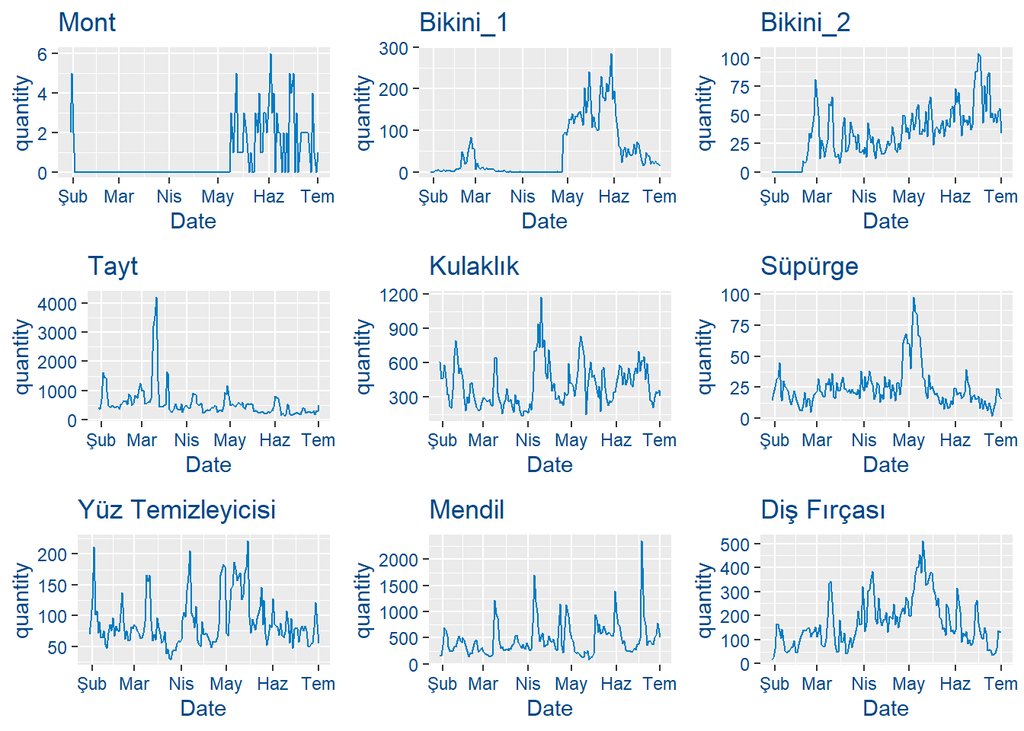

```r
par(mfrow=c(3,3))
a<-ggplot(data = mont, aes(x = event_date, y = sold_count ,group=1))+
  geom_line(color = '#007cc3') + labs(title = 'Mont', x= "Date", y = "quantity") + theme(text=element_text(color="#004785"),axis.text=element_text(color="#004785"))

b<-ggplot(data = bikini_1, aes(x = event_date, y = sold_count ,group=1))+
  geom_line(color = '#007cc3') + labs(title = 'Bikini_1', x= "Date", y = "quantity") + theme(text=element_text(color="#004785"),axis.text=element_text(color="#004785"))

c<-ggplot(data = bikini_2, aes(x = event_date, y = sold_count ,group=1))+
  geom_line(color = '#007cc3') + labs(title = 'Bikini_2', x= "Date", y = "quantity") + theme(text=element_text(color="#004785"),axis.text=element_text(color="#004785"))

d<-ggplot(data = tayt, aes(x = event_date, y = sold_count ,group=1))+
  geom_line(color = '#007cc3') + labs(title = 'Tayt', x= "Date", y = "quantity") + theme(text=element_text(color="#004785"),axis.text=element_text(color="#004785"))

e<-ggplot(data = kulaklık, aes(x = event_date, y = sold_count ,group=1))+
  geom_line(color = '#007cc3') + labs(title = 'Kulaklık', x= "Date", y = "quantity") + theme(text=element_text(color="#004785"),axis.text=element_text(color="#004785"))

f<-ggplot(data = supurge, aes(x = event_date, y = sold_count ,group=1))+
  geom_line(color = '#007cc3') + labs(title = 'Süpürge', x= "Date", y = "quantity") + theme(text=element_text(color="#004785"),axis.text=element_text(color="#004785"))

g<-ggplot(data = yuz_temizleyicisi, aes(x = event_date, y = sold_count ,group=1))+
  geom_line(color = '#007cc3') + labs(title = 'Yüz Temizleyicisi', x= "Date", y = "quantity") + theme(text=element_text(color="#004785"),axis.text=element_text(color="#004785"))

h<-ggplot(data = mendil, aes(x = event_date, y = sold_count ,group=1))+
  geom_line(color = '#007cc3') + labs(title = 'Mendil', x= "Date", y = "quantity") + theme(text=element_text(color="#004785"),axis.text=element_text(color="#004785"))

j<-ggplot(data = dis_fircasi, aes(x = event_date, y = sold_count ,group=1))+
  geom_line(color = '#007cc3') + labs(title = 'Diş Fırçası', x= "Date", y = "quantity") + theme(text=element_text(color="#004785"),axis.text=element_text(color="#004785"))

grid.arrange(a,b,c,d,e,f,g,h,j ,
             ncol = 3, nrow = 3)
```

We see that there is a quite different range of sales quantity patterns. For example: mont and bikini_1 have some long zero timeline of sales, whereas bikini_2 seems to have an increasing trend and some seasonality.The other 6 products actually resemble each other in terms of noiseness.They all have single or multiple peaks and other than that they follow a white noisy pattern which is pretty good for modelling purposes but it harms our forecasting power, hence randomness effect play a significant role here by pushing us into this trade-off situation where modelling benefits from noiseness but forecasting takes damage from it.

### Statistical Analysis

We now maybe interested in stationarity , partial correlation and autocorrelation relationships between lags , this will be useful in further statistical analysis and it will help us in arima part of the model.Here a handful function to study mentioned statistics :

```r
Statistical_Analysis <- function(X){
  input_data = X
  KPSS_test= ur.kpss(input_data$sold_count)
  print(summary(KPSS_test))
  acf(input_data$sold_count)
  pacf(input_data$sold_count)
}
```

Mont-statistics :

```r
Statistical_Analysis(mont)
```

```
##
## #######################
## # KPSS Unit Root Test #
## #######################
##
## Test is of type: mu with 4 lags.
##
## Value of test-statistic is: 1.5466
##
## Critical value for a significance level of:
##                 10pct  5pct 2.5pct  1pct
## critical values 0.347 0.463  0.574 0.739
```

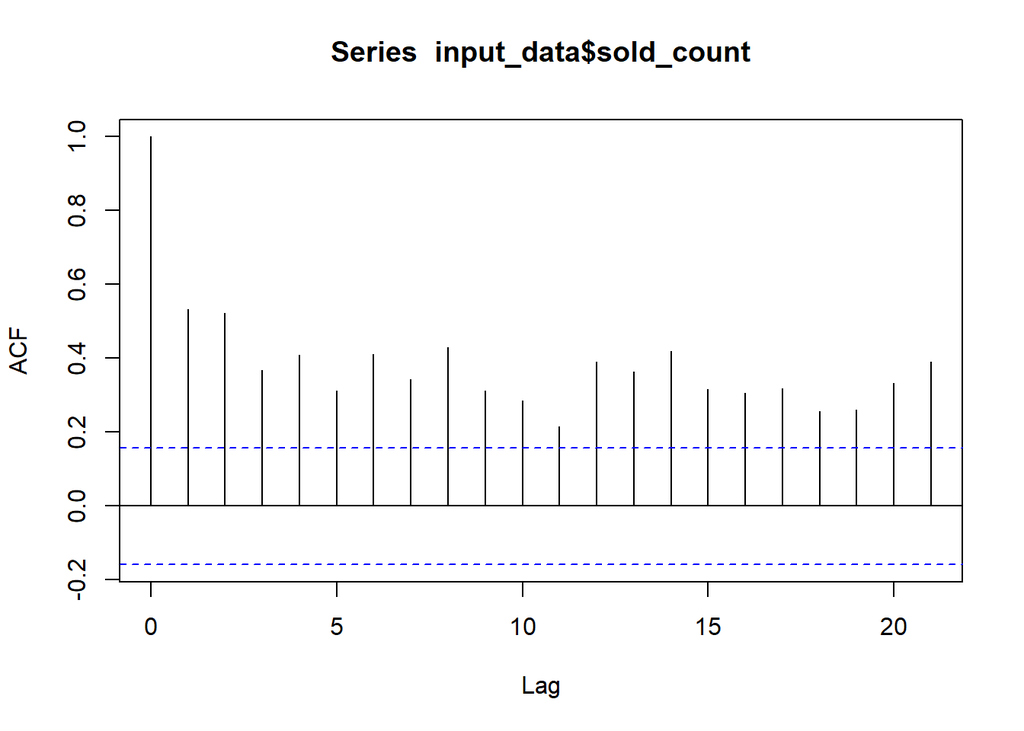

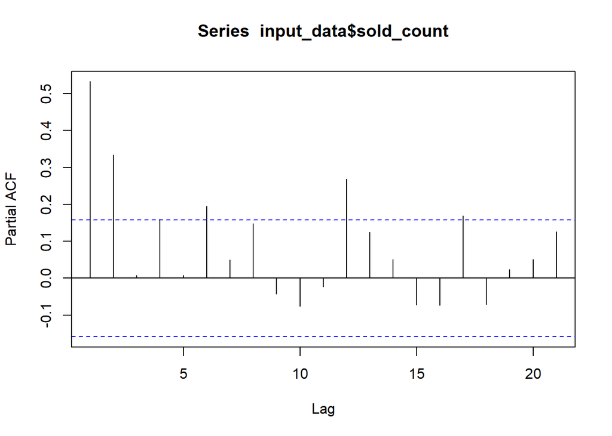

Bikini_1-statistics :

```r
Statistical_Analysis(bikini_1)
```

```
##
## #######################
## # KPSS Unit Root Test #
## #######################
##
## Test is of type: mu with 4 lags.
##
## Value of test-statistic is: 1.1446
##
## Critical value for a significance level of:
##                 10pct  5pct 2.5pct  1pct
## critical values 0.347 0.463  0.574 0.739
```

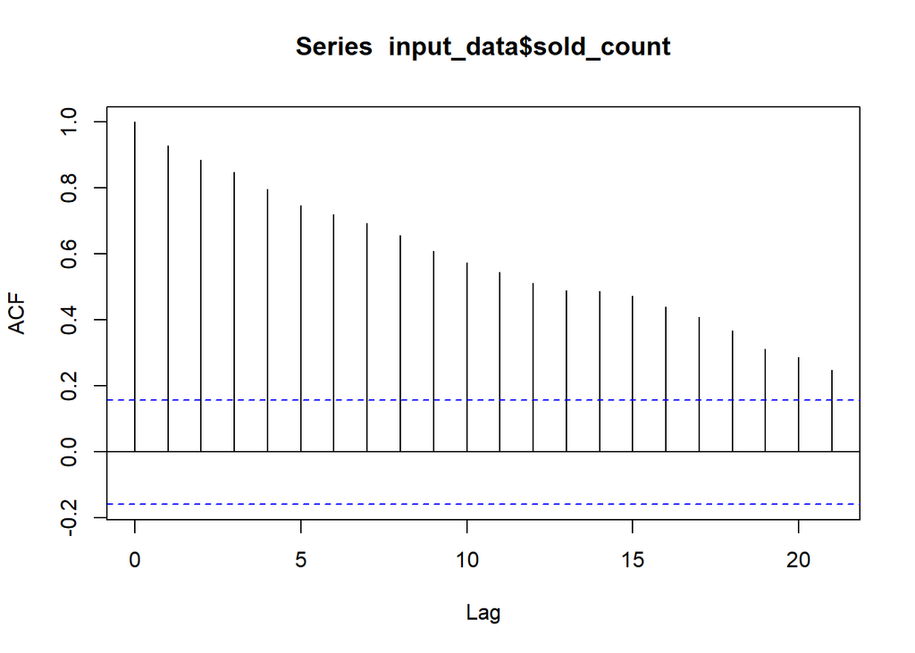

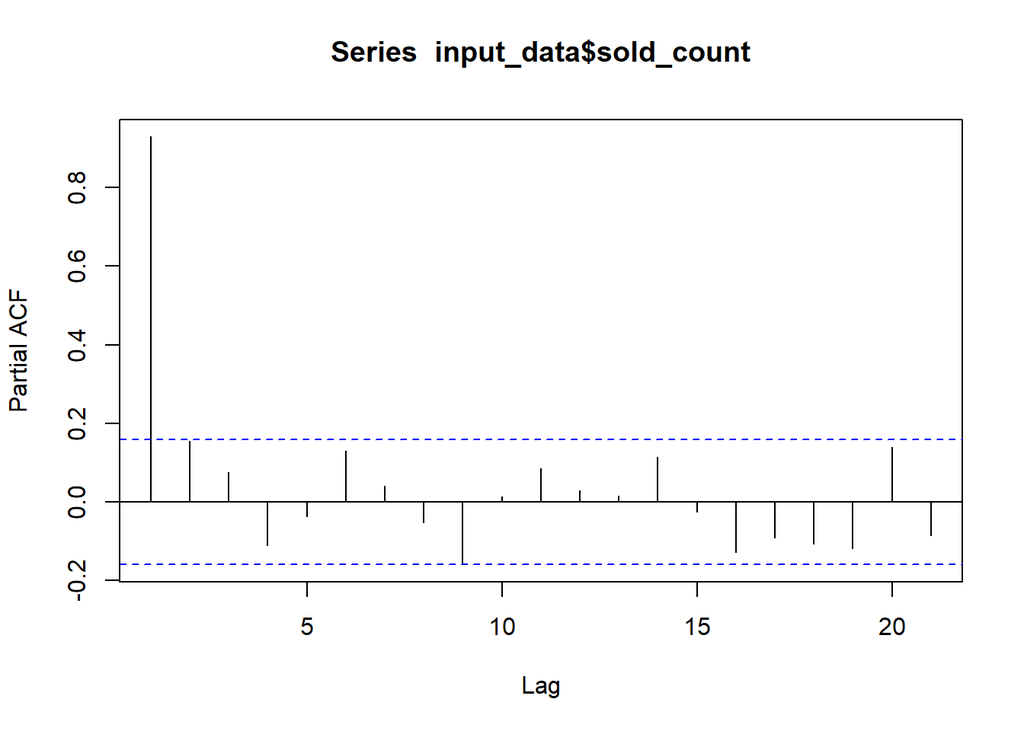

Bikini_2-statistics :

```r
Statistical_Analysis(bikini_2)
```

```
##
## #######################
## # KPSS Unit Root Test #
## #######################
##
## Test is of type: mu with 4 lags.
##
## Value of test-statistic is: 1.9639
##
## Critical value for a significance level of:
##                 10pct  5pct 2.5pct  1pct
## critical values 0.347 0.463  0.574 0.739
```

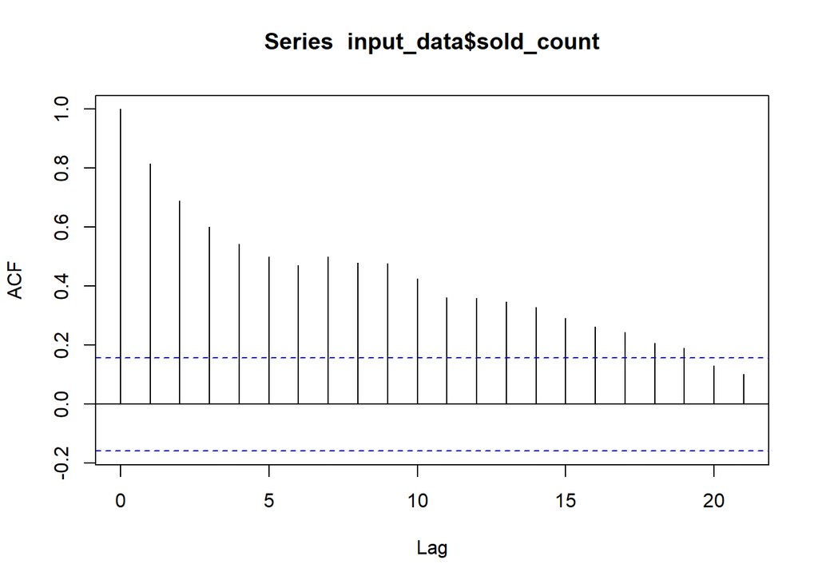

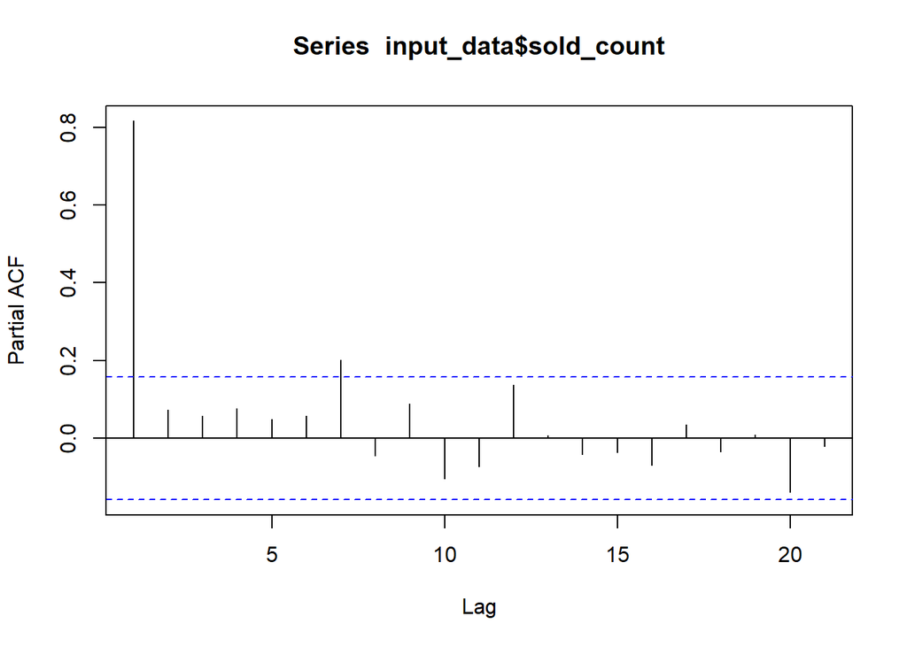

Tayt-statistics :

```r
Statistical_Analysis(tayt)
```

```
##
## #######################
## # KPSS Unit Root Test #
## #######################
##
## Test is of type: mu with 4 lags.
##
## Value of test-statistic is: 0.8459
##
## Critical value for a significance level of:
##                 10pct  5pct 2.5pct  1pct
## critical values 0.347 0.463  0.574 0.739
```

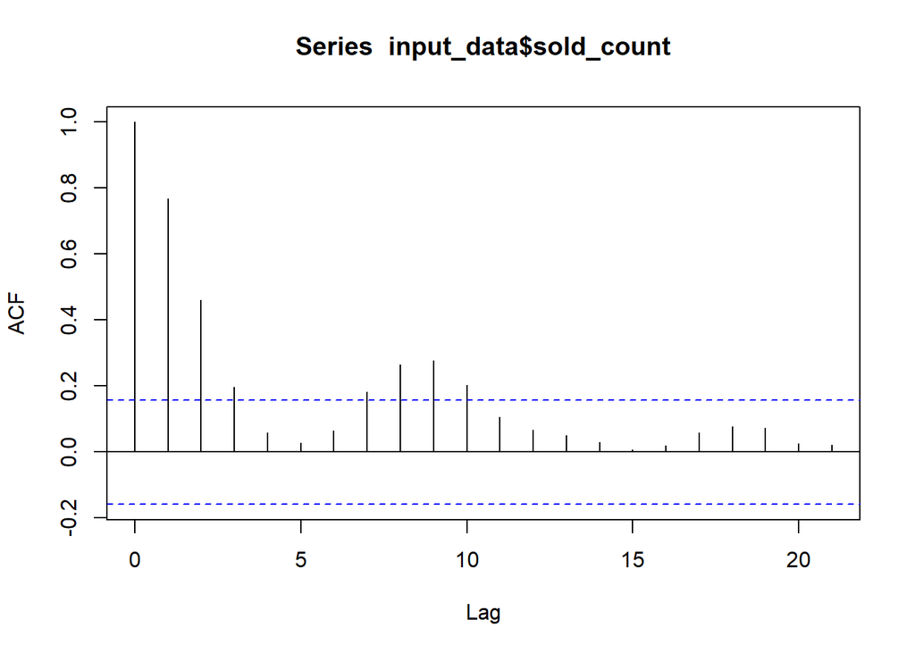

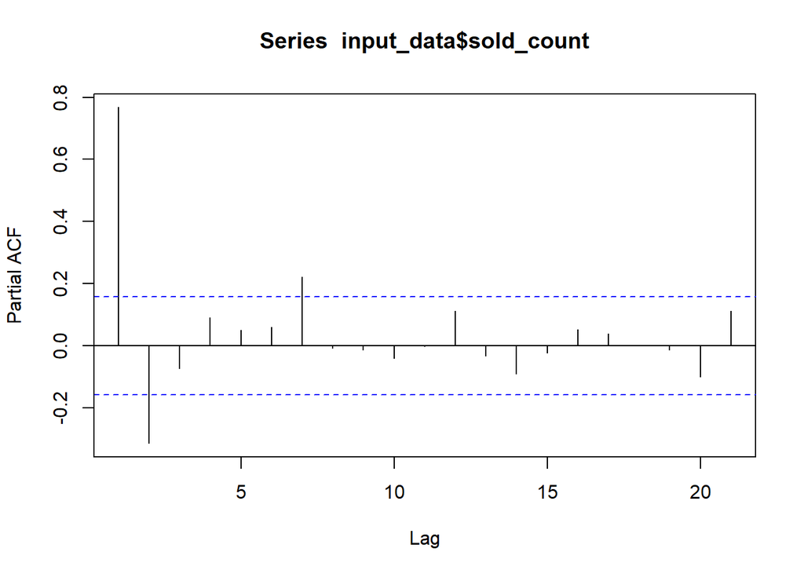

Kulaklik-statistics :

```r
Statistical_Analysis(kulaklık)
```

```
##
## #######################
## # KPSS Unit Root Test #
## #######################
##
## Test is of type: mu with 4 lags.
##
## Value of test-statistic is: 0.2252
##
## Critical value for a significance level of:
##                 10pct  5pct 2.5pct  1pct
## critical values 0.347 0.463  0.574 0.739
```

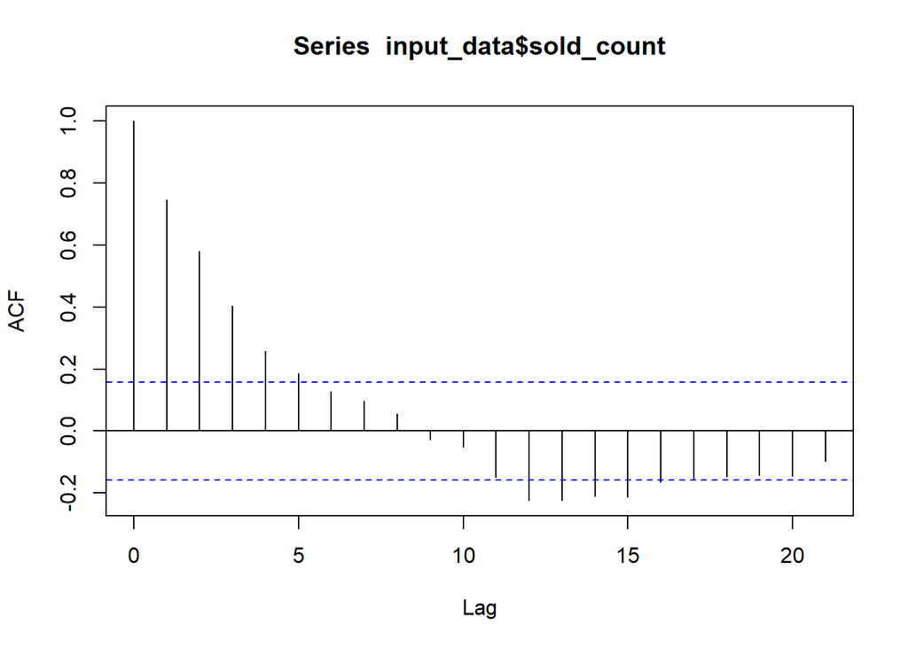

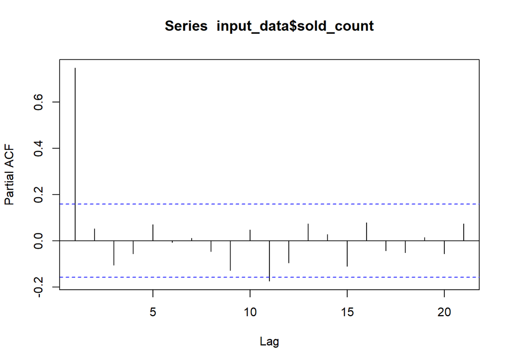

Supurge-statistics :

```r
Statistical_Analysis(supurge)
```

```
##
## #######################
## # KPSS Unit Root Test #
## #######################
##
## Test is of type: mu with 4 lags.
##
## Value of test-statistic is: 0.2692
##
## Critical value for a significance level of:
##                 10pct  5pct 2.5pct  1pct
## critical values 0.347 0.463  0.574 0.739
```

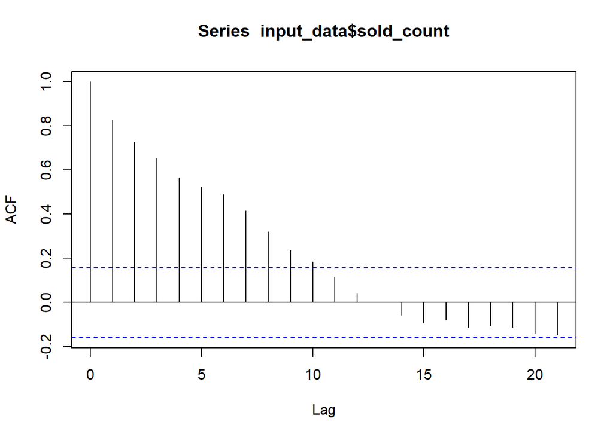

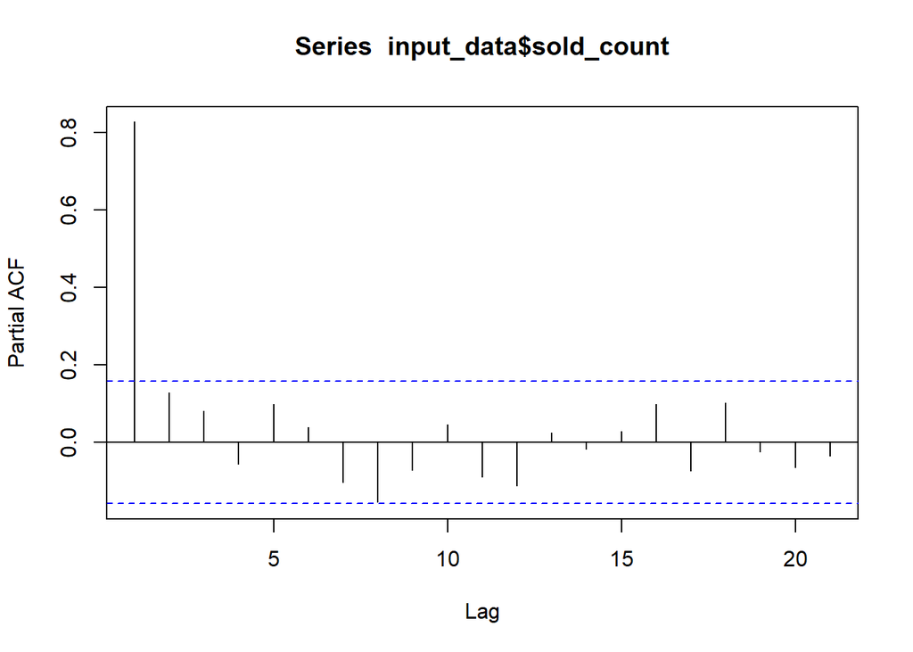

Yuz_temizleyicisi-statistics :

```r
Statistical_Analysis(yuz_temizleyicisi)
```

```
##
## #######################
## # KPSS Unit Root Test #
## #######################
##
## Test is of type: mu with 4 lags.
##
## Value of test-statistic is: 0.1987
##
## Critical value for a significance level of:
##                 10pct  5pct 2.5pct  1pct
## critical values 0.347 0.463  0.574 0.739
```

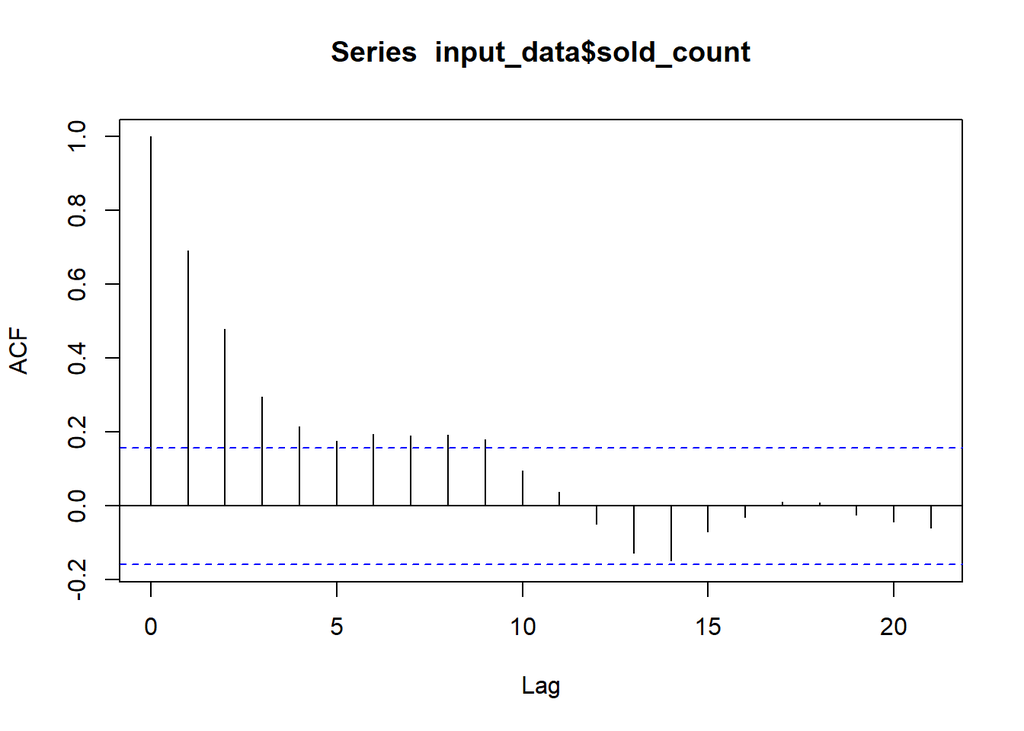

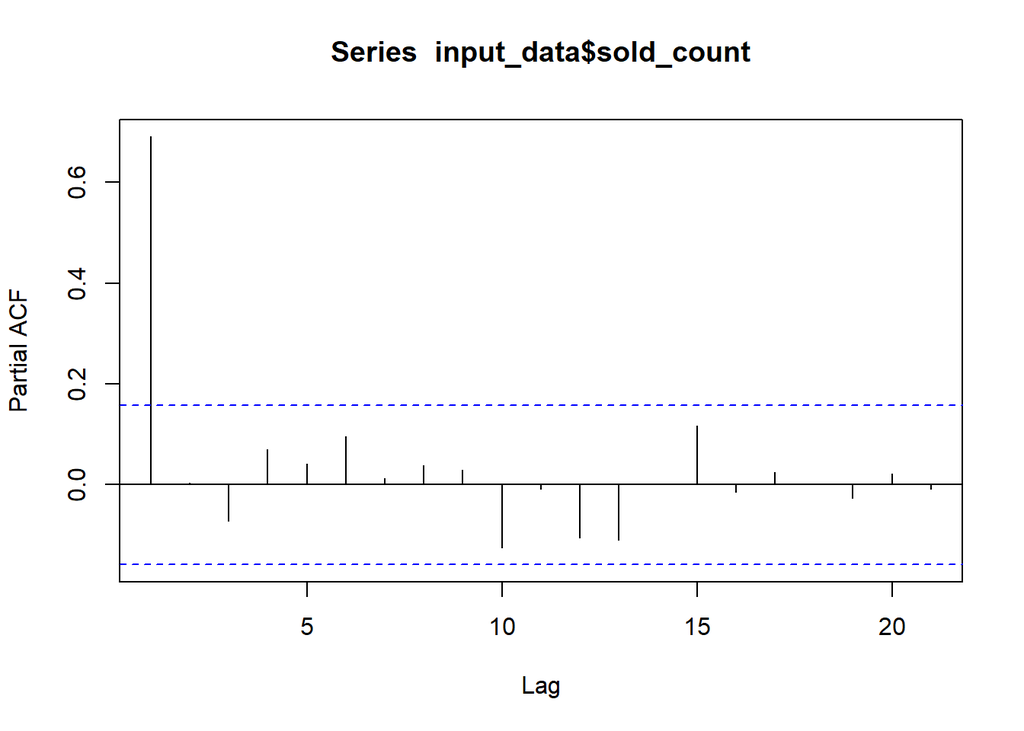

Mendil-statistics :

```r
Statistical_Analysis(mendil)
```

```
##
## #######################
## # KPSS Unit Root Test #
## #######################
##
## Test is of type: mu with 4 lags.
##
## Value of test-statistic is: 0.3888
##
## Critical value for a significance level of:
##                 10pct  5pct 2.5pct  1pct
## critical values 0.347 0.463  0.574 0.739
```

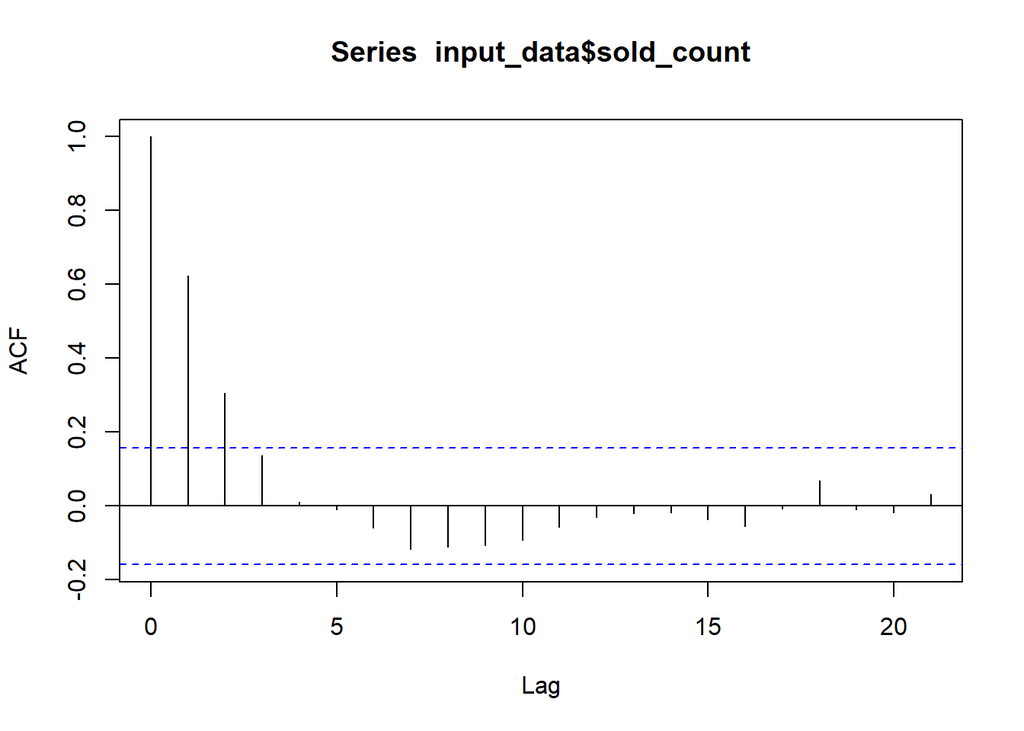

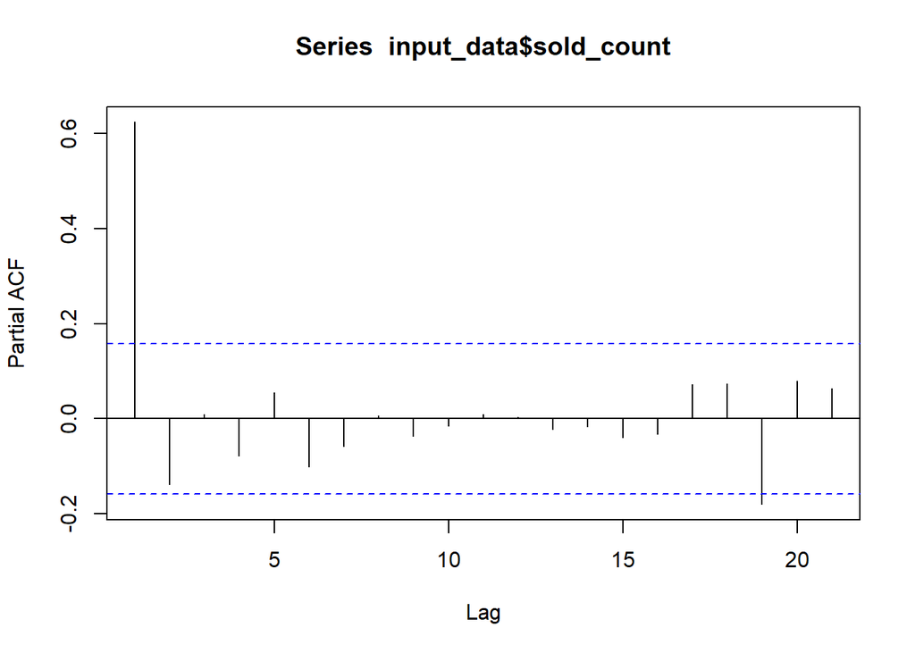

Dis_fircasi-statistics :

```r
Statistical_Analysis(dis_fircasi)
```

```
##
## #######################
## # KPSS Unit Root Test #
## #######################
##
## Test is of type: mu with 4 lags.
##
## Value of test-statistic is: 0.6284
##
## Critical value for a significance level of:
##                 10pct  5pct 2.5pct  1pct
## critical values 0.347 0.463  0.574 0.739
```

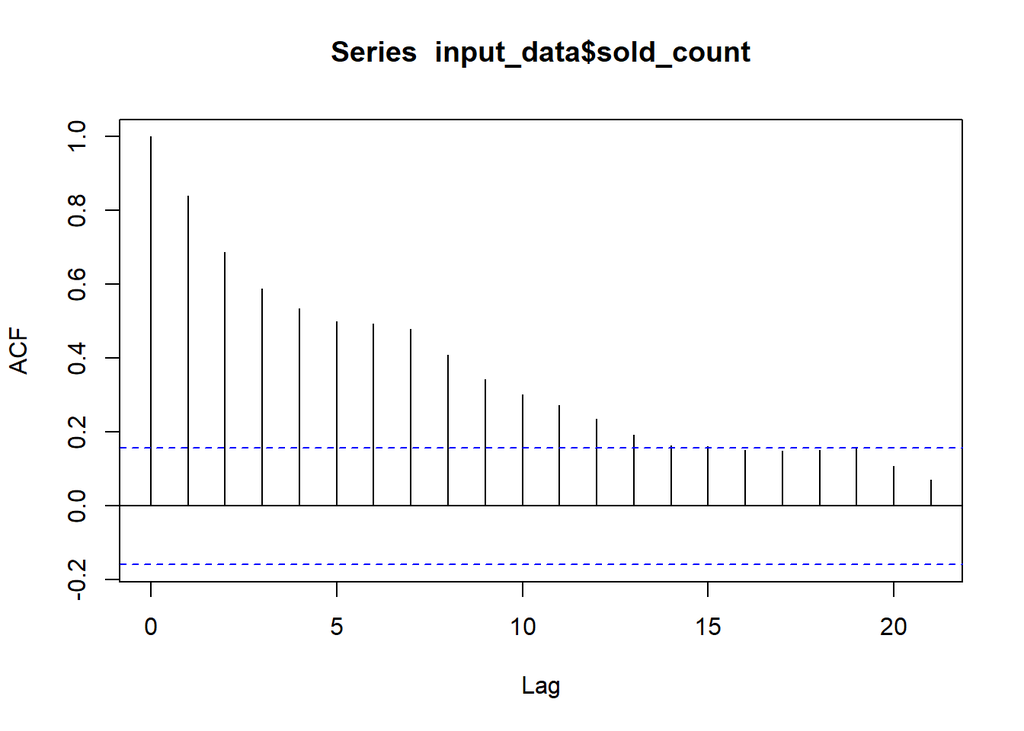

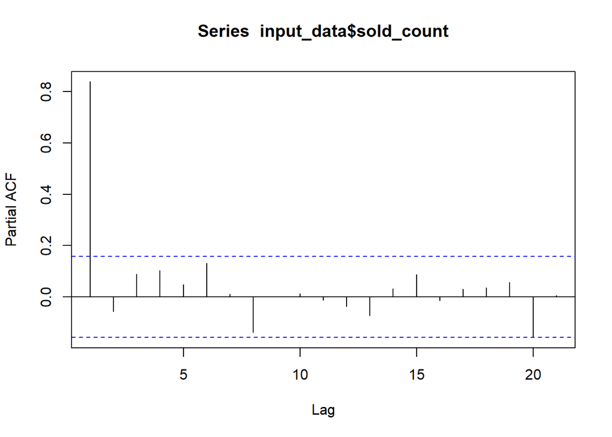

To evaluate each individual product in terms of stationarity and autocorrelations we need to mention a general approach. In KPSS test, we desire to approve the null hypothesis stating that the tested data is stationary, hence we want to get the lowest possible test-statistic even below 10-pct confidence interval. From ACF graph , we can get the notion of selecting correct number of moving average lags and from PACF graph , we can decide a sufficient p parameter for autoregression in ARIMA, but we wont do arima that way, its just a statistical perspective and this investigations help us to familiarize with the product sales data.